# Outline

### 1. Data Gathering

```
   1.1. Import of Libraries
   1.2. Loading the Manually Downloaded data
   1.3. Programmatic Download of Dataset using the request Method
   1.4. Scrapping using the tweepy API
```

### 2. Accessing Data

```
   2.1. Quality Issues
   2.2. Tidiness
```

### 3. Cleaning Data

```
   3.1. Define Issue
   3.2. Code
   3.3. Test
```

### 4. Data Storage

```
   4.1. Merging the three dataframes
   4.2. Storing the master dataframe in .csv format
```

### 5. Analysis & Visualization

# 1. Data Gathering

Data gathering involves getting data from several sources to be used for analysis. Data itself is usually dirty and can appear in different format. During the course of this project, I worked on dataset of four different format. There include:

- .csv file format - Comma Separated Values
- .tsv file format - Tab Separated Values
- json file format - JavaScript Object Notation
- .txt file format - Text

During the process of data gathering, the following where applied;

### 1.1. Import of Libraries

I used a few python libraries, during the course of this project. Python libraries help access external functionalities by just importing and applying a few functions of built-in libraries. The libraries I used during this wrangle act include:

- pandas: It helps to read data into DataFrame (or Tables, i.e. Data in rows and columns) and it built in functions are largely used for basic exploratory data analysis. I Used this library for read files into DataFrame, and other exploratory analysis which I did.
- requests: This library as the names, I used it to send request for the collection of data from different url (web page)
- tweepy: It is an APIs built for twitter developers. I was supposed to use this but my requested to join the developers environ was denied.
- BeautifulSoup from bs4: Use for webscrapping as well.
- os: I used to navigate file pathway
- json: I used this to handle the data that was gotten from twitter

### 1.2. Loading the Manually Downloaded data

A dataset was given already in csv format, which I downloaded and used the .read_csv(), method of the pandas library to load the data into a DataFrame

### 1.3. Programmatic Download of Dataset using the request Method

I also used the request library to access the .tsv file format that sent across. These are steps I took:

- I started by querying the url using a .get() method
- Then I created a folder and made sure the folder isn't existing already
- Thereafter, I read the contents of that webpage into the folder created
- Lastly, I read the .tsv file with the .read_csv() method of pandas with separator being tab

### 1.4. Scrapping using the tweepy API

# 2. Accessing Data

Accessing the datasets, I perfomed several analysis here, and I spotted a few issues that were associated with the dataset. Both the Quality and Tidiness Issue. There are documented in the wrangle_act.ipynb notebook. A hightlight of the issues include:

### 2.1. Quality Issues

```
Quality issues include:
1. Irrelevant character (in twitter_archive_enhanced['source']) - '<a href=' before and 'rel="nofollow">' after
2. Unnecessary character (in twitter_archive_enhanced['timestamp']) - The Presence of : & +0000
3. Columns with wrong datatype: The columns include
    * tweet_id being int instead of objects
    * rating_numerator and rating_denominator being int, instead of floats
    * retweet_count and favorite_count should be integers, not floats
4. Merged Date and Time (in the timestamp column)
5. Null Entries (in column 'name')
6. Unaccepted entries (in column 'name')
    * Entries with lower cases in the name columns are not accepted. Reason why these are not suppose to be in the name column is that there all start with small letters which is against the normal format for writing names
7. Missing values (some columns:)
    * in_reply_to_status_id
    * in_reply_to_user_id
    * retweeted_status_id
    * retweeted_status_user_id
    * retweeted_status_timestamp
    * expanded_urls
8. Irrelevant Columns [friends_count (in table tweet_json.txt)]
```

### 2.2. Tidiness

```
Tidness Issues include:
1. Dog stages
   * The four different columns doggo, floofer, pupper and puppo to become a single column
2. Different Tables
   * The three datasets to be merged into a master dataframe
```

# 3. Cleaning Data

I applied several techniques during the data cleaning task; I followed the Udacity presented standard for cleaning data, they involve;

- Define
- Code
- Test

Before I began the whole cleaning processes, I made a copy of the three datasets. Here are the techniques I applied in cleaning the issues encountered, they are;

### Quality Issues Cleaning

1. For Issue 1: To remove the irrelevant character, I applied the .str.replace() function to replace those characters with nothing, and that settles the issue
2. Issue 2: I extracted the values of the affected column, then used a .stip() function which is for removing charaters from a string. Then created an empty list where all the strip data where stored, this act was looped using the for loop. Thereafter, I replaced the affected values with the stripped values and this settled the issued.
3. Issue 3: Here, I applied the .astype() function to convert the affected columns to the required column datatypes.
4. Issue 4: This issue has to do with the date and time being merged. So I used the pd.to_date_time(DataFrame) to create two different columns. The columns are date (.dt.date) and time (.dt.time).
5. Issue 5: Entries with None as values. Here, converted the None values to numpy nan values using the numpy.nan() function. Thereafter, I decided to used the forward and backward fill method to fill in the nan values in the column. I didn't drop the None values because they were the majority, thus this will make use loose some information.]
6. Issue 6: This issue is as a result of assigning values that can't be peoples' name to the peoples' column. I decided to apply the same procedure as I did for the None values in issue 5.
7. Issue 7: I applied the .drop() function that was used to remove the columns from the datasets
8. Issue 8: I also applied the .drop() function in removing the columns from the tweet_json.txt files

   ```
        * friends_count (in table tweet_json.txt)
   ```

### Tidiness Issues Cleaning

1. Tidy 1: Firstly, I converted the None values in the different dog stages to nan values. Secondly, I joined the four stages of dogs into one column called; Dog_Stages. Finally, I dropped the single columns of the dog stages
2. Different Tables The three datasets to be merged into a master dataframe

# 4. Data Storage

- Using pandas.to_csv() function to save the master data in csv format

# 5. Analysis & Visualization

I perform several analysis with the indsights reported in the module below. Some of the visualizations below were used to derive the insights.

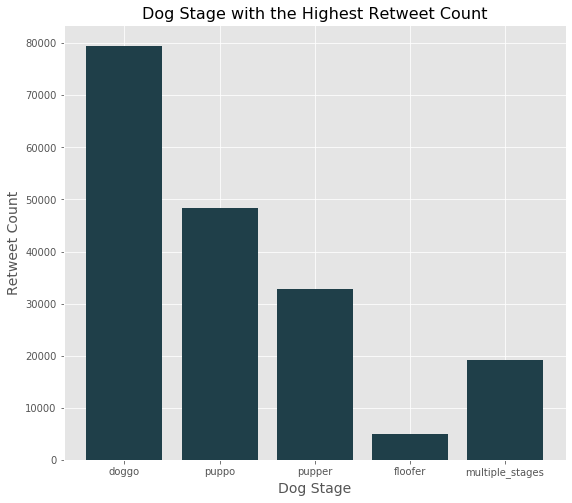

# Dog Stage with the Highest Retweet Count

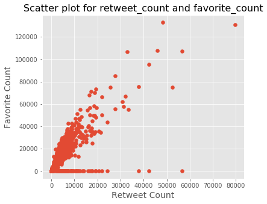

# Correlation between retweet_count and favorite_count

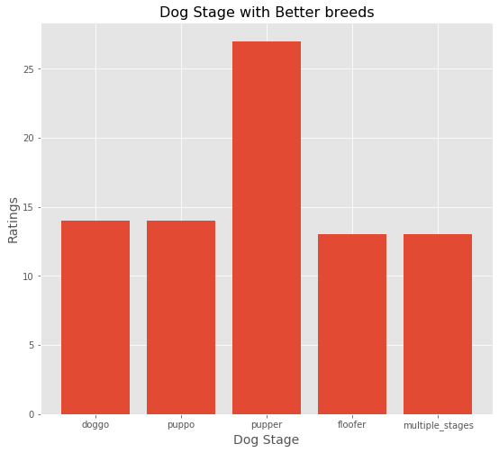

# Dog Stage with Better breeds

# 6. Insights

The following insights were derived from my analysis

### Further Analysis

Here are a few other questions that could be addressed

- Who made the highest retweet?
- Which source has the highest retweet count?
- Does the confidence prediction have impact on the ratings of the dogs?

### Sources of Data

- 'https://d17h27t6h515a5.cloudfront.net/topher/2017/August/599fd2ad_image-predictions/image-predictions.tsv'
- 'https://video.udacity-data.com/topher/2018/November/5be5fb7d_tweet-json/tweet-json.txt'

### Other sources of information

- https://www.w3schools.com/js/js_json_intro.asp
- https://www.geeksforgeeks.org/insert-image-in-a-jupyter-notebook/#:~:text=Method%201%3A%20Direct%20insertion%20using%20the%20edit%20menu&text=first%2C%20change%20the%20type%20of,Edit%20%2D%3E%20insert%20image.
- https://stackoverflow.com/questions/18575012/centering-text-in-ipython-notebook-markdown-heading-cells
- https://google.com